# 1 .Boolean and Logical Operators

# 9. Pandas reading json and html file

Not Important for now

# 10. Matplotlib Library

```python
import matplotlib.pyplot as plt
%matplotlib inline
import numpy as np
import pandas as pd
```

```python
subject=['eng','tamil','math','soc','sci']
stud1=[10,20,30,40,5]
stud2=[55,65,33,67,70]
stud3=[45,53,55,90,50]
```

```python
a=np.arange(40,60)
b=np.arange(50,60)
```

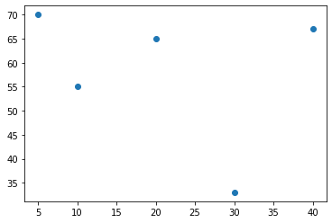

```python
plt.scatter(stud1,stud2)
```

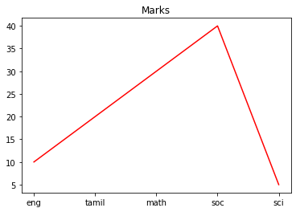

```python
plt.plot(subject,stud1,c='r')
plt.title('Marks')
```

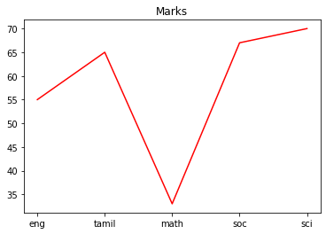

```python
plt.plot(subject,stud2,c='r')
plt.title('Marks')
```

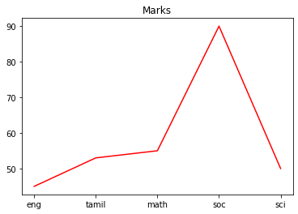

```python
plt.plot(subject,stud3,c='r')
plt.title('Marks')
```

Creating Subplot

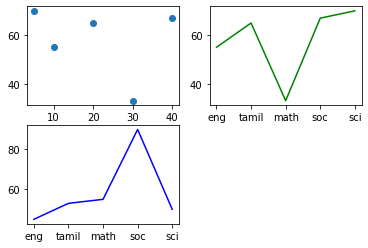

```python
plt.subplot(2,2,1)
plt.scatter(stud1,stud2)
plt.subplot(2,2,2)
print('\n')
plt.plot(subject,stud2,c='g')
plt.subplot(2,2,3)
plt.plot(subject,stud3,c='b')
```

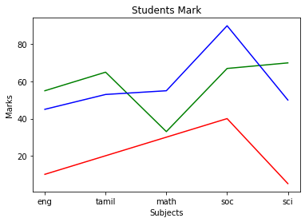

```python
plt.subplot(1,1,1)
plt.plot(subject,stud1,c='r')
plt.subplot(1,1,1)
plt.plot(subject,stud2,c='g')
plt.subplot(1,1,1)
plt.plot(subject,stud3,c='b')
plt.title('Students Mark')
plt.xlabel('Subjects')
plt.ylabel('Marks')
```

Making a Sine wave in daigram

```python
np.pi
```

```
3.141592653589793
```

```python
x=np.arange(0,4*np.pi,0.5)
y_sin=np.sin(x)
y_cos=np.cos(x)
```

```python
x
```

```
array([ 0. ,  0.5,  1. ,  1.5,  2. ,  2.5,  3. ,  3.5,  4. ,  4.5,  5. ,
        5.5,  6. ,  6.5,  7. ,  7.5,  8. ,  8.5,  9. ,  9.5, 10. , 10.5,
       11. , 11.5, 12. , 12.5])
```

```python
y_sin
```

```
array([ 0.        ,  0.47942554,  0.84147098,  0.99749499,  0.90929743,
        0.59847214,  0.14112001, -0.35078323, -0.7568025 , -0.97753012,
       -0.95892427, -0.70554033, -0.2794155 ,  0.21511999,  0.6569866 ,
        0.93799998,  0.98935825,  0.79848711,  0.41211849, -0.07515112,
       -0.54402111, -0.87969576, -0.99999021, -0.87545217, -0.53657292,
       -0.0663219 ])
```

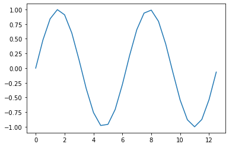

```python
plt.plot(x,y_sin)
```

Making a Cosine wave

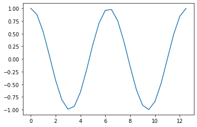

```python
plt.plot(x,y_cos)
```

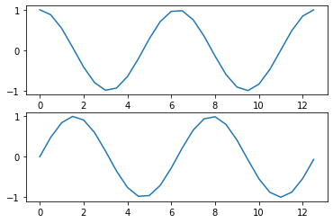

```python
plt.subplot(2,1,1)
plt.plot(x,y_cos)
plt.subplot(2,1,2)
plt.plot(x,y_sin)
```

Bar Plot

```python
x=np.arange(1,11)
y=3*x+5
```

```python
print(x)
print(y)
```

```
[ 1  2  3  4  5  6  7  8  9 10]
[ 8 11 14 17 20 23 26 29 32 35]
```

```
<BarContainer object of 10 artists>
```

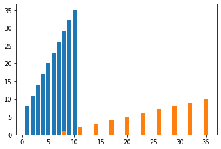

```python
plt.bar(x,y)
plt.bar(y,x)
```

```python
x=[1,2,34]
y=[11,16,9]
x1=[3,9,11]
y1=[6,15,7]
```

```
<BarContainer object of 3 artists>
```

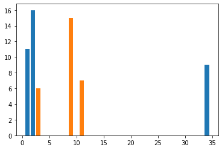

```python
plt.bar(x,y)
print(plt.bar(x1,y1))
```

Histogram

histogram is used for find the density of occurance of a no. with in a range.

```python
a=np.array([1,2,34,11,16,9,3,9,11,6,15,7])
```

```python
a
```

```
array([ 1,  2, 34, 11, 16,  9,  3,  9, 11,  6, 15,  7])
```

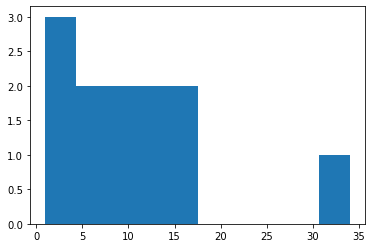

```python
plt.hist(a)
```

Box plot

```
{'whiskers': [<matplotlib.lines.Line2D at 0x21739ff9700>,
 'caps': [<matplotlib.lines.Line2D at 0x21739ff9dc0>,
 'boxes': [<matplotlib.lines.Line2D at 0x21739ff93a0>,
 'medians': [<matplotlib.lines.Line2D at 0x2173a0064c0>,
 'fliers': [<matplotlib.lines.Line2D at 0x2173a006820>,
 'means': []}
```

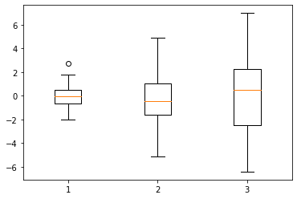

```python
data=[np.random.normal(0,std,100) for std in range(1,4)]
plt.boxplot(data,vert=True,patch_artist=False)
```

# 11.Seaborn

```python
import seaborn as sbn
```

```python
df=sbn.load_dataset('tips')
```

```python
df
```

|  | total_bill | tip | sex | smoker | day | time | size |
| --- | --- | --- | --- | --- | --- | --- | --- |
| 0 | 16.99 | 1.01 | Female | No | Sun | Dinner | 2 |
| 1 | 10.34 | 1.66 | Male | No | Sun | Dinner | 3 |
| 2 | 21.01 | 3.50 | Male | No | Sun | Dinner | 3 |
| 3 | 23.68 | 3.31 | Male | No | Sun | Dinner | 2 |
| 4 | 24.59 | 3.61 | Female | No | Sun | Dinner | 4 |
| ... | ... | ... | ... | ... | ... | ... | ... |
| 239 | 29.03 | 5.92 | Male | No | Sat | Dinner | 3 |
| 240 | 27.18 | 2.00 | Female | Yes | Sat | Dinner | 2 |
| 241 | 22.67 | 2.00 | Male | Yes | Sat | Dinner | 2 |
| 242 | 17.82 | 1.75 | Male | No | Sat | Dinner | 2 |
| 243 | 18.78 | 3.00 | Female | No | Thur | Dinner | 2 |

244 rows × 7 columns

```python
df.corr()
```

|  | total_bill | tip | size |
| --- | --- | --- | --- |
| total_bill | 1.000000 | 0.675734 | 0.598315 |
| tip | 0.675734 | 1.000000 | 0.489299 |
| size | 0.598315 | 0.489299 | 1.000000 |

# Joint plot

A joint plot allows to study the relationship between the two numerical variables. The central chart display their correlation. It is usually a scatterplot, a hexabinn plot, a 2D histogram or density plot.

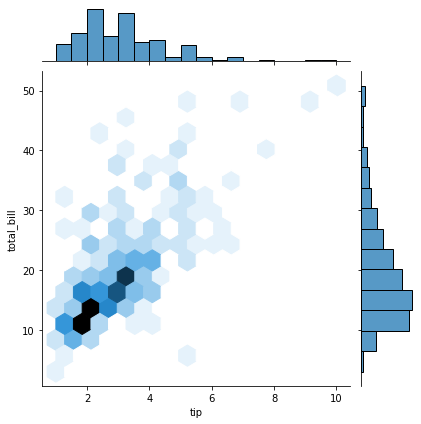

```python
sbn.jointplot(x='tip',y='total_bill',data=df,kind='hex',)
```

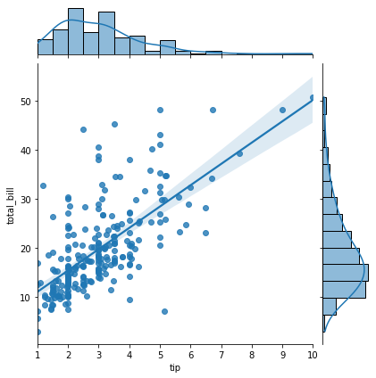

```python
sbn.jointplot(x='tip',y='total_bill',data= df, kind='reg')
```

# pair plot

A pair plot is also known as a scatter plot, in which one variable in the same data row is matched with another variable values.

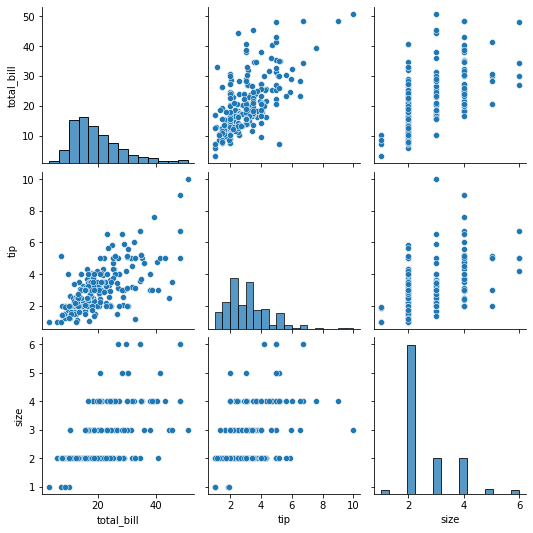

```python
sbn.pairplot(df)
```

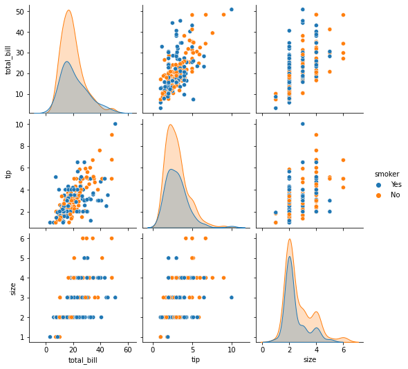

```python
sbn.pairplot(df, hue='smoker')
```

# Dist plot

[output not shown]

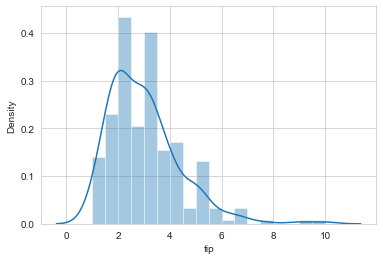

```python
sbn.distplot(df['tip'])
```

# Categorical Plot

Box Plot Violine plot count plot bar plot

# Count plot

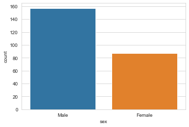

```python
sbn.countplot('sex',data=df,)
```

[output not shown]

[figure not shown]

```python
sbn.countplot(x)
```

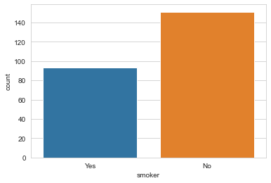

```python
sbn.countplot('smoker',data=df,)
```

# Bar Plot

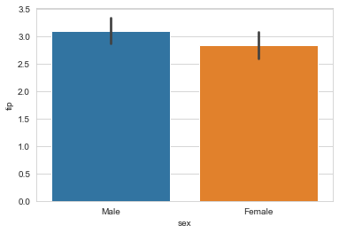

```python
sbn.set_style("whitegrid")
sbn.barplot(x='sex',y='tip',data=df)
```

# Box plot

A box plot is a graph that presents information from a five number summary

[output not shown]

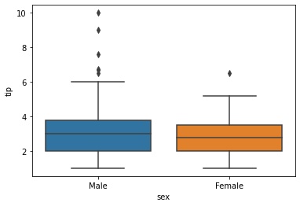

```python
sbn.boxplot('sex','tip',data=df)
```

[output not shown]

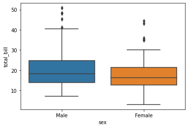

```python
sbn.boxplot('sex','total_bill',data=df)
```

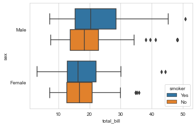

```python
## categorize my data based on some other categories
sbn.boxplot(x='total_bill',y='sex',hue='smoker',data=df)
```

# Violin Plot

violin plot helps us to see both the distribution of data in terms of KDE and the box plot

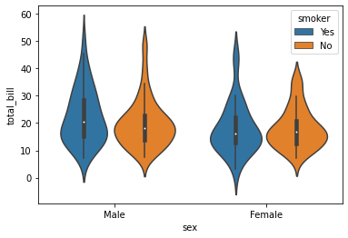

```python
sbn.violinplot(x='sex',y='total_bill',data=df, hue='smoker')
```

# 12.EXPLORATORY DATA ANALYSIS

# 13.Function in Python

```python
### example
num=33
```

```python
if num %2==0:
    print('The number is even ')
else:
    print('the number is odd')
```

```
the number is odd
```

```python
def  athik(num):
    if num %2==0:
        print('The number is even ')
    else:
        print('the number is odd')
```

```python
athik(100)
```

```
The number is even
```

```python
def hello():
    num = input('entr u r dept')
    print('hello everyone MSc')
```

```python
hello()
```

```
entr u r deptMsc
hello everyone MSc
```

```python
even_odd(55)
```

```
the number is odd
```

```python
   W = input("Weight is: ")

measure = input("Entred value is in (K)g or (L)bs: ")

if measure == 'k' or 'k':
    print('Weight in lb: ' + str(float(W) * 2.205))
else:
    print('Weignt in Kg: ' + str(float(W) / 2.205))
```

```
Weight is: 85
Entred value is in (K)g or (L)bs: l
Weight in lb: 187.425
```

```python
wght()
```

# Difference b/w Print and return

Function using print

```python
def noteql (a):
    if a%2!=0:
        print("The number is odd")
    else:
        print("The number is even")
```

```python
b=noteql(22)
```

```
The number is even
```

```python
print(b)
```

```
None
```

It shows None because print statement doesn't return anything it just show

# now in return function

```python
def noteql (a):
    if a%2!=0:
        return "The number is odd"
    else:
        return "The number is even"
```

```python
b=noteql(52)
```

```python
b
```

```
'The number is even'
```

here we can clearly see that return function returns something to the function when we save it in a variable 'b'.

# Positional argument and keyword argument

This is when a the second parameter is initialised with a value like age=19

```python
def name(name,age=19):
    return "My name is {} and age is {}".format(name,age)
```

```python
c=name('Athikur')
```

```python
print(c)
```

```
My name is Athikur and age is 19
```

what if parameter is not initialised with a value like age.

```python
def name(name,age):
    return "My name is {} and age is {}".format(name,age)
```

```python
name('athikur',20)
```

```
'My name is athikur and age is 20'
```

Simple example functions

```python
## cumulative addition of even numbers and odd numbers in a list
list=[1,2,3,4,5,6,7,8,9,10,11]
list1=[1,2,3,4,5,6,7,8,10,9,10,11,13,15,17,19]

def oddoreven (list):
    even_num=0
    odd_num=0
    for i in list:
        if i%2==0:
            even_num=even_num+i
        else:
            odd_num=odd_num+i
    return even_num,odd_num
```

```python
print(oddoreven(list))
print(oddoreven(list1))
```

```
(30, 36)
(40, 100)
```

# Lambda Function

annonymous function or a function with no name

```python
## Normal way with few lines of code
def addition(a,b):
    return a+b

add=addition(5,10)
add
```

```
15
```

```python
## with use of lambda function
add=lambda a,b:a+b
add(5,5)
```

```
10
```

```python
def even (num):
    return num%2==0
even(21)
```

```
False
```

```python
## in lambda function
even =lambda num:num%2==0
even(54)
```

```
True
```

```python
lst[1,2,3,4]
```

```python
seq=lambda a:a+7
seq(3)
```

```
10
```

# Map function

```python
import numpy as np
import pandas as pd
```

```python
## Normal function
def evenodd1 (num):
    if num%2==0:
        return "The number {} is even". format(num)
    else:
        return "The number {} is odd". format(num)
```

```python
evenodd1(25)
```

```
'The number 25 is odd'
```

What if i have list of number

```python
newlist=[1,2,3,4,5,6,7,8,9,10]
```

```python
map(evenodd1,newlist)
```

[output not shown]

# Filter function

```python
def even1 (num):
    if num%2==0:
        return True
```

```python
lst=[1,2,3,4,5,6,7,8]
```

```python
filter(even1,lst)
```

```
<filter at 0x1e895965070>
```

```python
list(filter(even1,lst))
```

[output not shown]